# lab5

Abeoseh Flemister

2026-04-02

## R Markdown

1. This question uses data from this paper:

https://science.sciencemag.org/content/347/6217/78

Variation in cancer risk among tissues can be explained by the number of stem cell divisions.

Science 02 Jan 2015: Vol. 347, Issue 6217, pp. 78-81

```r
cancer_df <- read.csv(url("https://fodorclasses.github.io/classes/stats2020/cancerRisk.txt"), sep= "\t", header = TRUE)

head(cancer_df)
```

```
##                                      Cancer_type Lifetime_cancer_risk
## 1                         Acute_myeloid_leukemia               0.0041
## 2                           Basal_cell_carcinoma               0.3000
## 3                   Chronic_lymphocytic_leukemia               0.0052
## 4                      Colorectal_adenocarcinoma               0.0480
## 5             Colorectal_adenocarcinoma_with_FAP               1.0000
## 6 Colorectal_adenocarcinoma_with__Lynch_syndrome               0.5000
##   CumulativeCellDivisions
## 1               1.299e+11
## 2               3.550e+12
## 3               1.299e+11
## 4               1.168e+12
## 5               1.168e+12
## 6               1.168e+12
```

## Including Plots

On a **log10-log10** scale graph `Lifetime_cancer_risk` (on the y-axis) vs. `CumulativeCellDivisions` (on the x-axis). (This reproduces Fig. 1 from the paper).

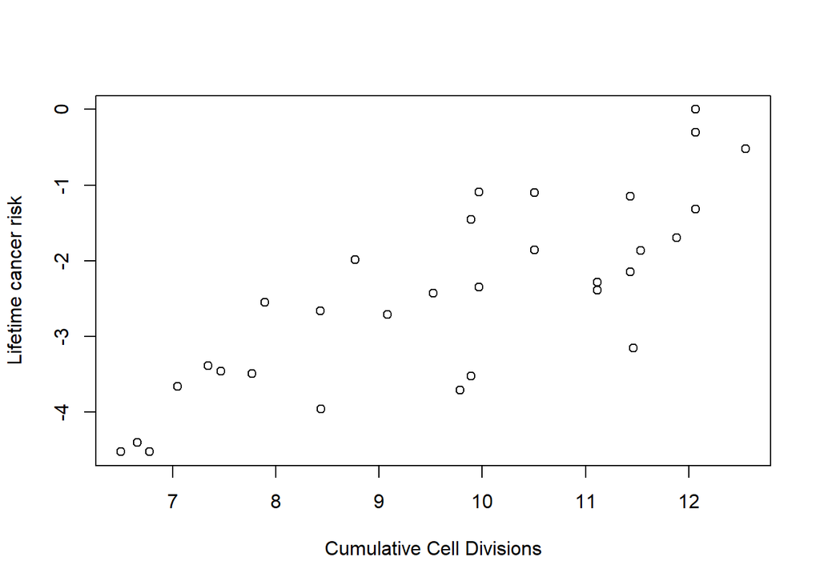

**(1B):** Using the lm function, fit a linear model with Lifetime_cancer_risk as the Y variable and CumulativeCellDivisions as the x-data. Add the regression line to the plot using the function abline(myLm) (where myLm is the linear model you created).

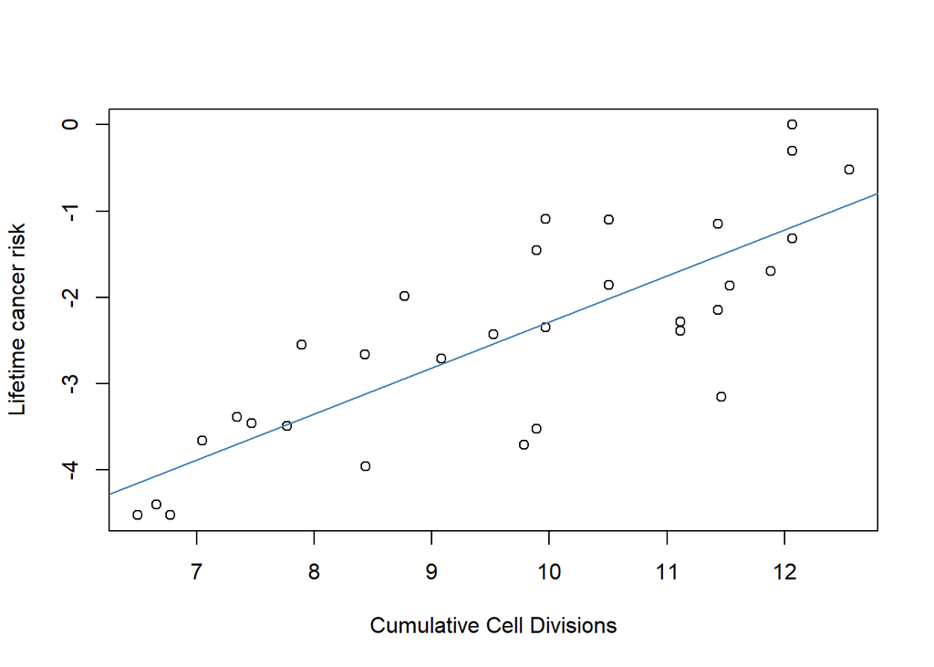

```r
lm_cancer <- lm(log10(cancer_df$Lifetime_cancer_risk) ~ log10(cancer_df$CumulativeCellDivisions))

# str(summary(lm_cancer))
# summary(lm_cancer)
# intercept = summary(lm_cancer)$coefficients[1]
# intercept
# slope = summary(lm_cancer)$coefficients[2]
# slope

plot(log10(cancer_df$CumulativeCellDivisions), log10(cancer_df$Lifetime_cancer_risk), xlab = "Cumulative Cell Divisions", ylab = "Lifetime cancer risk")
abline(lm_cancer, col="steelblue")
```

```r
# abline(a = intercept, b = slope)
```

(**1C):** What is the p-value for the null hypothesis that the slope of the regression between these two variables is zero? What is the r-squared value of the model?

**The p-value between the null hypothesis that the slope of the regression between lifetime cancer risk and cumulative cell divisions is 5.12e-08. Therefore, I reject the null hypothesis at a p-value of 5.12e-08. Practically, this means I am confident with a 5.12e-08 chance of a false positive, that lifetime cancer risk is dependent on cumulative cell divisions.**

```r
summary(lm_cancer)
```

```
##
## Call:
## lm(formula = log10(cancer_df$Lifetime_cancer_risk) ~ log10(cancer_df$CumulativeCellDivisions))
##
## Residuals:
##      Min       1Q   Median       3Q      Max
## -1.65115 -0.46564  0.06167  0.43180  1.21040
##
## Coefficients:
##                                          Estimate Std. Error t value Pr(>|t|)
## (Intercept)                              -7.61081    0.72292 -10.528 2.03e-11
## log10(cancer_df$CumulativeCellDivisions)  0.53264    0.07317   7.279 5.12e-08
##
## (Intercept)                              ***
## log10(cancer_df$CumulativeCellDivisions) ***
## ---
## Signif. codes:  0 '***' 0.001 '**' 0.01 '*' 0.05 '.' 0.1 ' ' 1
##
## Residual standard error: 0.7491 on 29 degrees of freedom
## Multiple R-squared:  0.6463, Adjusted R-squared:  0.6341
## F-statistic: 52.99 on 1 and 29 DF,  p-value: 5.124e-08
```

**(1D):** Are the assumptions of constant variance and normal distribution of the residues reasonable for this model? Justify your answer.

**After log10 transformation, the assumption of constant variance is semi-reasonable since variance from the regession line is roughly equal for all points. On the normal Q-Q plot we can see that the residuals are not entirely normally distributed. Despite this, linear regression is fairly robust against mild deviations from the assumptions. Without log10 transformations, the assumptions of equal variance and normal distributions of the residuals are entirely invalid.**

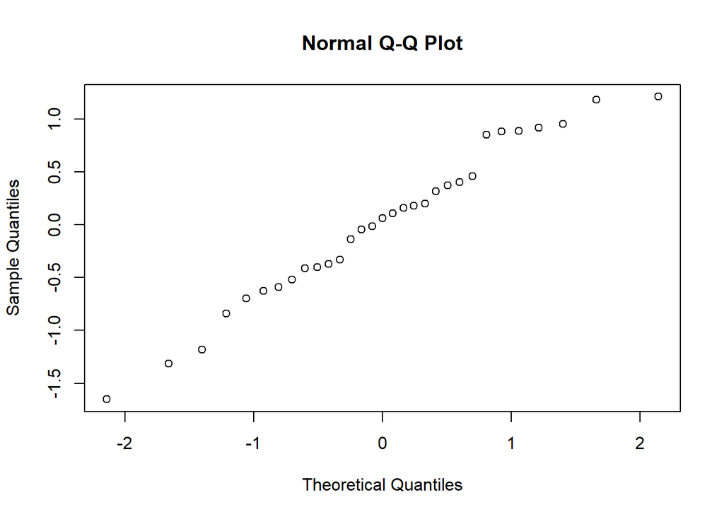

```r
qqnorm(residuals(lm_cancer))
```

2. Consider the case-control file for the colorectal adenomas data set that is here:

http://afodor.github.io/classes/stats2015/caseControlData.txt

A separate file gives obesity (BMI) data for these same subjects:

http://afodor.github.io/classes/stats2015/BMI_Data.txt

For each OTU in the spreadsheet, generate a p-value from linear regression comparing BMI to the relative abundance of each OTU. Graph out all the p-values. Do they appear uniformly distributed? Does the microbial community appear to be influencing body weight in this cohort? Are any of these associations significant at a 10% false discovery rate?

Hints: To lookup the ids in the BMI table, you will need to some processing on the “sample” column in the caseControl file. The following code will convert the a sampleID so that it will match the BMI file.

# remove case and control

key <- sub(“case”, ““, sampleID)

key <- sub(“control”, ““, key)

# remove extraneous information from the suffix

key <- strsplit( key, “_”)[[1]][1]

Also, to get the p-value out of the linear model try:

anova( myLm)$“Pr(>F)”[1]

```r
col_adema <- read.csv(url("http://afodor.github.io/classes/stats2015/caseControlData.txt"), sep = "\t")

col_adema$studyid <- gsub("_.*", "", col_adema$sample)

bmi <- read.csv(url("http://afodor.github.io/classes/stats2015/BMI_Data.txt"), sep = "\t")

bmi_ColAdema <- merge(bmi, col_adema,  by = "studyid")
bmi_ColAdema$studyid <- NULL
bmi_ColAdema$sample <- NULL

print(paste("rows in col_adema:", nrow(col_adema), "rows in bmi", nrow(bmi), "rows in bmi_ColAdema", nrow(bmi_ColAdema)))
```

```
## [1] "rows in col_adema: 71 rows in bmi 165 rows in bmi_ColAdema 71"
```

```r
head(bmi)
```

```
##      studyid      bmi
## 1 D5-601-120 24.37128
## 2 D5-601-618 25.52469
## 3 D5-602-100 39.36138
## 4 D5-602-667 29.40466
## 5 D5-602-805 25.41915
## 6 D5-603-574 24.42873
```

```r
head(col_adema[,c(1:10)])
```

```
##                      sample    OTU338 OTU339    OTU332    OTU333    OTU159
## 1 D5-686-525_2_1_380control 0.0000000      0 0.3384939 0.0000000 0.0000000
## 2   D5-655-442_2_1_1500case 0.0000000      0 0.6382781 0.0000000 0.0000000
## 3   D5-607-356_2_1_1355case 0.0000000      0 0.8752417 0.4192582 1.2160313
## 4    D5-635-911_1_1_332case 0.6971691      0 0.5150642 0.3297935 0.3297935
## 5 D5-623-944_2_1_965control 0.0000000      0 0.0000000 0.8387050 0.0000000
## 6 D5-649-142_2_1_943control 0.4278568      0 0.0000000 0.4278568 1.5386454
##      OTU330    OTU158   OTU331   OTU157
## 1 0.0000000 0.0000000 0.000000 0.000000
## 2 0.0000000 0.0000000 0.000000 1.469189
## 3 0.0000000 0.6285482 0.000000 0.000000
## 4 0.3297935 1.5983105 0.195477 0.000000
## 5 0.0000000 1.1971227 0.000000 0.000000
## 6 0.0000000 0.0000000 0.000000 0.000000
```

```r
head(bmi_ColAdema[,c(1:10)])
```

```
##        bmi    OTU338 OTU339    OTU332    OTU333    OTU159    OTU330    OTU158
## 1 24.37128 0.0000000      0 0.4719822 0.0000000 0.0000000 0.8384794 0.4719822
## 2 25.52469 0.0000000      0 0.4126489 0.0000000 0.4126489 0.9508810 1.1363708
## 3 39.36138 0.0000000      0 0.0000000 0.0000000 1.4482462 0.0000000 1.6191494
## 4 29.40466 0.0000000      0 0.2888068 0.8239284 0.8239284 0.5835937 1.6289788
## 5 25.41915 0.0000000      0 0.0000000 0.5387236 0.5387236 0.0000000 1.5781564
## 6 24.42873 0.3241116      0 0.3241116 0.0000000 1.0407024 0.0000000 2.2853016
##     OTU331    OTU157
## 1 0.000000 0.4719822
## 2 1.082888 1.1363708
## 3 0.000000 1.4172500
## 4 0.000000 1.3564729
## 5 0.000000 0.0000000
## 6 0.000000 0.0000000
```

```r
pvals = vector(length = length(bmi_ColAdema)-1)
i = 1

for ( col in colnames(bmi_ColAdema)[2:length(bmi_ColAdema)] ){
  lm_bmi <- lm( bmi_ColAdema[["bmi"]] ~ bmi_ColAdema[[col]] )
  # print("done")
  pvals[i] = anova( lm_bmi)$"Pr(>F)"[1]

  i = i + 1

}
```

**By chance, approximately 0.10 of the p-values are significant. Therefore, I can conclude that the the positive p-values are by chance.**

[output not shown]

**At a p-value of 0.10 I expect 0.10 of the samples to be positive just by chance.**

```
## [1] "The porportion of significant p-values is 0.104761904761905"
```

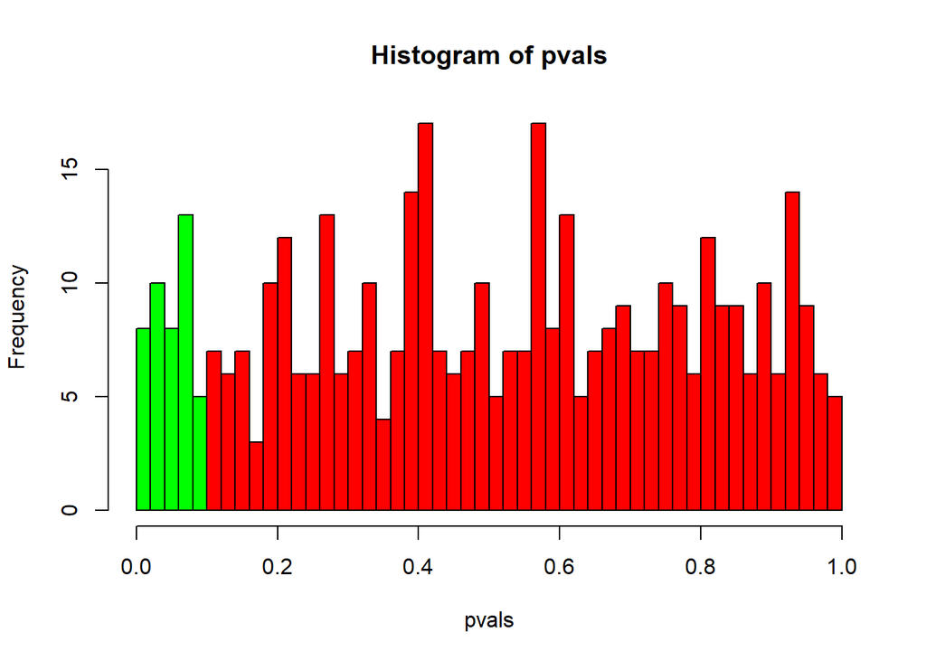

**None of the p-values that pass the Bonferroni correction, this makes sense since I expected 0.10 of the p-values to be significant by chance which was the case.**

```r
FDR_threshold <- 0.10 / length(pvals)

bonferonni_pvals = pvals[pvals <= FDR_threshold]

print(paste(length(bonferonni_pvals), "p-values passed bonferonni correction."))
```

```
## [1] "0 p-values passed bonferonni correction."
```

```r
sorted_pvals <- sort(pvals)

for (i in length(sorted_pvals)){bh_pvals <- length(sorted_pvals * sorted_pvals[i])/i}

print(paste(sum(bh_pvals < 0.10), "p-values were passed benjamin-hochberg correction."))
```

```
## [1] "0 p-values were passed benjamin-hochberg correction."
```